# R Notebook

# Differences in stroke diagnoses between different demographics

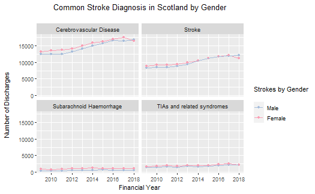

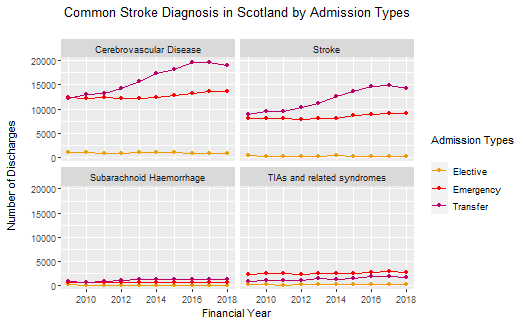

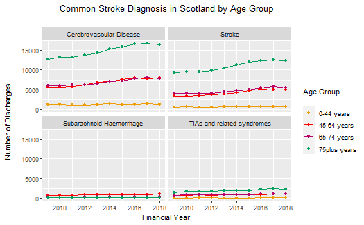

```
 [1] "NHS Grampian"                  "NHS Tayside"                   "NHS Highland"                  "NHS Forth Valley"              "NHS Dumfries and Galloway"
 [6] "NHS Ayrshire and Arran"        "NHS Lothian"                   "NHS Western Isles"             "NHS Orkney"                    "NHS Borders"
[11] "NHS Shetland"                  "Scotland"                      "NHS Fife"                      "NHS Greater Glasgow and Clyde" "NHS Lanarkshire"
```

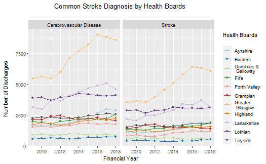

Omitted the NHS Western Isles, NHS Orkney, NHS Shetland, Subarachnoid Haemorrhage, TIAs and related syndromes doe to very small numbers

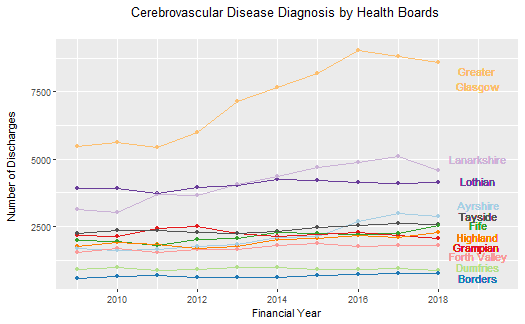

“NHS Grampian” : Aberdeen, Aberdeenshire and Moray.

“NHS Tayside” : Angus, the City of Dundee and Perth and Kinross.

NHS Forth Valley : Clackmannanshire, Falkirk and Stirling

“NHS Ayrshire and Arran” : North Ayrshire South Ayrshire East Ayrshire

“NHS Lothian” : City of Edinburgh, East Lothian, Midlothian and West Lothian

NHS Greater Glasgow and Clyde : City of Glasgow, East Dunbartonshire, East Renfrewshire, Inverclyde, Renfrewshire and West Dunbartonshire.

NHS Lanarkshire : North Lanarkshire and South Lanarkshire

# Differences in number of cases by health board vs by local authority

| council_name | financial_year | admission_type | age_group | sex | diagnosis | number_of_discharges | crude_rate | easr |
| --- | --- | --- | --- | --- | --- | --- | --- | --- |
| Aberdeen City | 2009 | All | All | All | Cerebrovascular Disease | 874 | 402.7278592 | 500.6892428 |
| Aberdeen City | 2009 | All | All | All | Stroke | 615 | 283.3840199 | 351.3758639 |
| Aberdeen City | 2009 | All | All | All | Subarachnoid Haemorrhage | 40 | 18.4314810 | 20.4882212 |
| Aberdeen City | 2009 | All | All | All | TIAs and related syndromes | 90 | 41.4708322 | 53.1040935 |
| Aberdeen City | 2009 | All | All | Male | Cerebrovascular Disease | 427 | 398.2354532 | 565.4250980 |
| Aberdeen City | 2009 | All | All | Male | Stroke | 304 | 283.5212594 | 402.1740512 |
| Aberdeen City | 2009 | All | All | Male | Subarachnoid Haemorrhage | 10 | 9.3263572 | 9.3724839 |
| Aberdeen City | 2009 | All | All | Male | TIAs and related syndromes | 41 | 38.2380646 | 57.2005151 |
| Aberdeen City | 2009 | All | All | Female | Cerebrovascular Disease | 447 | 407.1149485 | 435.9533876 |
| Aberdeen City | 2009 | All | All | Female | Stroke | 311 | 283.2499977 | 300.5776766 |

[output cut: 990 more lines]

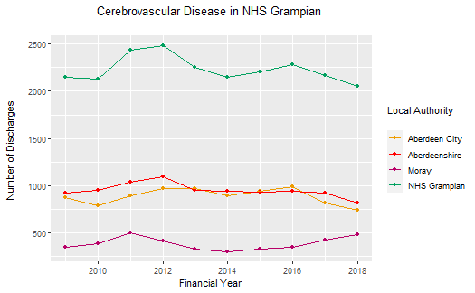

| financial_year | sum_of_discharges |
| --- | --- |
| 2009 | 2147 |
| 2010 | 2131 |
| 2011 | 2439 |
| 2012 | 2482 |
| 2013 | 2252 |
| 2014 | 2144 |
| 2015 | 2208 |
| 2016 | 2281 |
| 2017 | 2172 |
| 2018 | 2046 |

| hb_name | financial_year | number_of_discharges |
| --- | --- | --- |
| NHS Grampian | 2009 | 2147 |
| NHS Grampian | 2010 | 2131 |
| NHS Grampian | 2011 | 2439 |
| NHS Grampian | 2012 | 2482 |
| NHS Grampian | 2013 | 2252 |
| NHS Grampian | 2014 | 2144 |
| NHS Grampian | 2015 | 2208 |
| NHS Grampian | 2016 | 2285 |
| NHS Grampian | 2017 | 2172 |
| NHS Grampian | 2018 | 2052 |

| financial_year | sum_of_discharges |
| --- | --- |
| 2009 | 3948 |
| 2010 | 4004 |
| 2011 | 4618 |
| 2012 | 4658 |
| 2013 | 4135 |
| 2014 | 3983 |
| 2015 | 4146 |
| 2016 | 4273 |
| 2017 | 4084 |
| 2018 | 3825 |

| financial_year | sum_of_discharges |
| --- | --- |
| 2009 | 3948 |
| 2010 | 4004 |
| 2011 | 4618 |
| 2012 | 4658 |
| 2013 | 4135 |
| 2014 | 3983 |
| 2015 | 4146 |
| 2016 | 4281 |
| 2017 | 4084 |
| 2018 | 3831 |

NHS Grampian across all the four types of strokes has an extra 8, 0.2% in 2016/17 and an extra 6, 0.2% in 2018/19 compared to the local authority’s

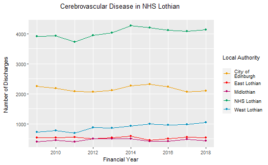

| financial_year | sum_of_discharges |
| --- | --- |
| 2009 | 3915 |
| 2010 | 3928 |
| 2011 | 3718 |
| 2012 | 3943 |
| 2013 | 4031 |
| 2014 | 4264 |
| 2015 | 4193 |
| 2016 | 4118 |
| 2017 | 4082 |
| 2018 | 4101 |

| hb_name | financial_year | number_of_discharges |
| --- | --- | --- |
| NHS Lothian | 2009 | 3915 |
| NHS Lothian | 2010 | 3928 |
| NHS Lothian | 2011 | 3718 |
| NHS Lothian | 2012 | 3943 |
| NHS Lothian | 2013 | 4031 |
| NHS Lothian | 2014 | 4264 |
| NHS Lothian | 2015 | 4193 |
| NHS Lothian | 2016 | 4118 |
| NHS Lothian | 2017 | 4087 |
| NHS Lothian | 2018 | 4125 |

For Cerebrovascular Disease NHS Lothian has an extra 5, 0.1% in 2017/18 and an extra 24, 0.6% in 2018/19 compared to the local authority’s

| financial_year | sum_of_discharges |
| --- | --- |
| 2009 | 7349 |
| 2010 | 7455 |
| 2011 | 7055 |
| 2012 | 7503 |
| 2013 | 7647 |
| 2014 | 8168 |
| 2015 | 8010 |
| 2016 | 7867 |
| 2017 | 7814 |
| 2018 | 7868 |

| financial_year | sum_of_discharges |
| --- | --- |
| 2009 | 7349 |
| 2010 | 7455 |
| 2011 | 7055 |
| 2012 | 7503 |
| 2013 | 7647 |
| 2014 | 8168 |
| 2015 | 8010 |
| 2016 | 7867 |
| 2017 | 7822 |
| 2018 | 7913 |

NHS Lothian across all the four types of strokes has an extra 8, 0.1% in 2017/18 and an extra 45, 0.6% in 2018/19 compared to the local authority’s

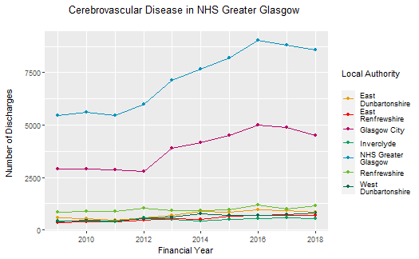

| financial_year | sum_of_discharges |
| --- | --- |
| 2009 | 10070 |
| 2010 | 10379 |
| 2011 | 10172 |
| 2012 | 11082 |
| 2013 | 13166 |
| 2014 | 14224 |
| 2015 | 15322 |
| 2016 | 17090 |
| 2017 | 16681 |
| 2018 | 16120 |

| financial_year | sum_of_discharges |
| --- | --- |
| 2009 | 10070 |
| 2010 | 10379 |
| 2011 | 10172 |
| 2012 | 11082 |
| 2013 | 13172 |
| 2014 | 14224 |
| 2015 | 15326 |
| 2016 | 17093 |
| 2017 | 16695 |
| 2018 | 16206 |

```
 [1] "Aberdeen City"         "Aberdeenshire"         "Angus"                 "Argyll and Bute"       "Clackmannanshire"      "Dumfries and Galloway" "Dundee City"
 [8] "East Ayrshire"         "East Dunbartonshire"   "East Lothian"          "East Renfrewshire"     "City of Edinburgh"     "Na h-Eileanan Siar"    "Falkirk"
[15] "Fife"                  "Highland"              "Inverclyde"            "Midlothian"            "Moray"                 "North Ayrshire"        "Orkney Islands"
[22] "Perth and Kinross"     "Renfrewshire"          "Scottish Borders"      "Shetland Islands"      "South Ayrshire"        "South Lanarkshire"     "Stirling"
[29] "West Dunbartonshire"   "West Lothian"          "Scotland"              "Glasgow City"          "North Lanarkshire"     "NHS Grampian"
```